# MA132Exercise

Tarak Patel

10/5/2021

## Packages

```r
library(tidyverse)
library(janitor)
```

## Read Data

Loading the file posted on Moodle:

```r
df1 = read_csv("C:/Users/Tarak/Documents/CollegeStuff/SeniorYear/Fall2021/DS241/Portfolio/Portfolio/data/raw/CU_ACAD_DEPT_WHEN_OFF_ENRL_22740.csv",
    skip = 1) %>% clean_names()
```

```
## * Term -> Term...7
## * Term -> Term...8
```

## Goal

Interested in predicting number of students enrolled in Calculus 2 in the spring.

Possible factors include: Students enrolled in Calculus 1 in the fall Took Calculus 2 in the fall and did not pass Transfer students

Variables in available data set: Prev Fall Calc 1 (x1), Prev Fall Calc 2 (x2) Following Spring Calc 2 (y)

## Step 1: Data Manipulation

Will need to use select(), filter(), summarize(), mutate(), etc to reach desired data set

```r
##df2 = df1 %>% select(course_id:catalog,term_7,term_8,tot_enrl,component) %>%
df2 = df1 %>% select(-instructor) %>%
  distinct %>%
  select(course_id:catalog,term_8,tot_enrl,component) %>%
  filter(subject == "MA",catalog %in% c(131,132), component == "LEC") %>%
  select(-component,-subject, -course_id) %>%
  rename(term = term_8) %>%
  mutate(course = case_when(catalog == 131 ~ "Calculus 1",
                            catalog == 132 ~ "Calculus 2")) %>%
  group_by(course,term) %>%
  summarise(enrl = sum(tot_enrl))
  ##filter()%>%
  ##filter(component == "LEC")
```

Data Processing

```r
df3 = df2 %>% separate(term, into = c("term","yr"), sep = " ", convert = TRUE) %>%
  filter(term != "Summer") %>% ungroup()
df4 = df3 %>% mutate(yr = yr - 2000) %>%
  mutate(ay = case_when(term == "Fall" ~str_c(yr,"-",yr+1),
                        term == "Spring" ~str_c(yr - 1, "-",yr)))
df5 = df4 %>% pivot_wider(ay,names_from = c(course,term),values_from = enrl) %>%
  clean_names() %>% arrange(ay)
```

Note that ay is the academic school year. We need df5 to widen the previous data frame. Now a visual will be created so a prediction can be made.

## Data Visualization

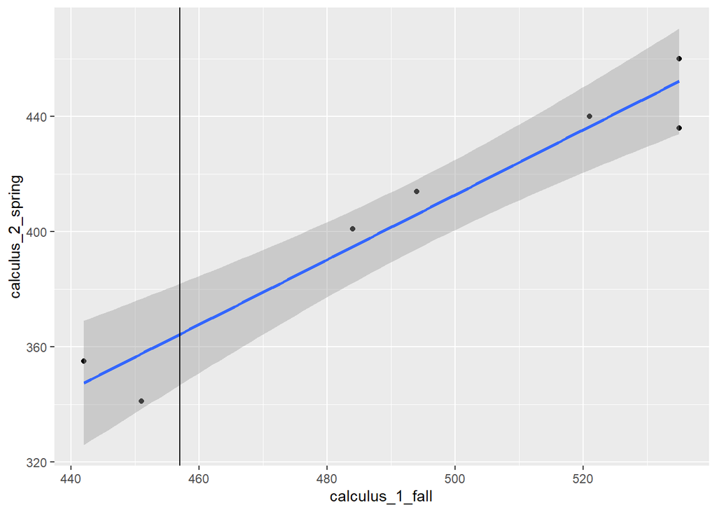

```r
df5 %>% filter(calculus_2_spring > 0) %>% ggplot(aes(x = calculus_1_fall, y = calculus_2_spring)) + geom_point() + geom_smooth(method = lm) + geom_vline(xintercept = tail(df5$calculus_1_fall,1))
```

Looking at this visual we can tell that if there are a lot of students enrolled in Calc 1 in the fall then there will be more students enrolled in Calc 2 in the following spring semester. I would say an accurate prediction for the number of students that are enrolled in Calc 2 next spring would be anywhere from 350 students to 365 students.